# **Data Analysis on Merged Movies Dataset**

First step of Data analysis is always have the questions to answer or to analyze on..

## 📌 **Exploratory Data Analysis (EDA)**

### Let us try to answer the following questions :

1. What is the average IMDb rating and Metascore?
2. What is the most common IMDb rating range for movies?
3. Is the IMDb rating distribution skewed toward high or low ratings?
4. Do movies with a high IMDb rating (above 9) also have high Metascores (above 90)?
5. Are there any outliers where movies have low Metascores but high IMDb ratings?
6. Has the number of movies increased significantly over time?
7. Did any specific years see a spike in movie releases?
8. Do different MPAA Ratings show significant differences in IMDb ratings?
9. Is Metascore per vote a better factor to consider for insights than just Metascore?
10. Do longer movies tend to have better ratings?
11. Are newer movies (after 2000) rated higher than older classics?
12. Is there a strong correlation between IMDb ratings and the number of votes?
13. Do higher Metascore movies receive more votes?
14. What does the correlation matrix reveal about relationships between different features?

```python
import numpy as np
import pandas as pd
import matplotlib.pyplot as plt
import seaborn as sns
```

## 1. Basic Summary Statistics

- What is the average IMDb rating and Metascore?

```python
df= pd.read_csv('merged_movies.csv')
df.describe()
```

|  | YEAR | IMDb Rating | Runtime | Votes | Metascore |
| --- | --- | --- | --- | --- | --- |
| count | 238.000000 | 238.000000 | 238.000000 | 2.380000e+02 | 238.000000 |
| mean | 1988.617647 | 8.301261 | 130.638655 | 7.524706e+05 | 80.701681 |
| std | 25.078123 | 0.230113 | 31.393980 | 5.813477e+05 | 13.287445 |
| min | 1921.000000 | 8.000000 | 68.000000 | 4.600000e+04 | 28.000000 |
| 25% | 1973.000000 | 8.100000 | 110.000000 | 2.700000e+05 | 73.000000 |
| 50% | 1995.500000 | 8.200000 | 127.500000 | 6.470000e+05 | 83.500000 |
| 75% | 2009.000000 | 8.400000 | 145.750000 | 1.100000e+06 | 90.000000 |
| max | 2024.000000 | 9.300000 | 321.000000 | 3.000000e+06 | 100.000000 |

```python
avg_imdb = df["IMDb Rating"].mean()
avg_metascore = df["Metascore"].mean()

print(f"Average IMDb Rating: {avg_imdb:.2f}")
print(f"Average Metascore: {avg_metascore:.2f}")
```

```
Average IMDb Rating: 8.30
Average Metascore: 80.70
```

## 2. Distribution of IMDb Ratings

- Most movies cluster around what range of ratings?
- Is the distribution skewed?
- The distribution skewed toward high or low ratings?

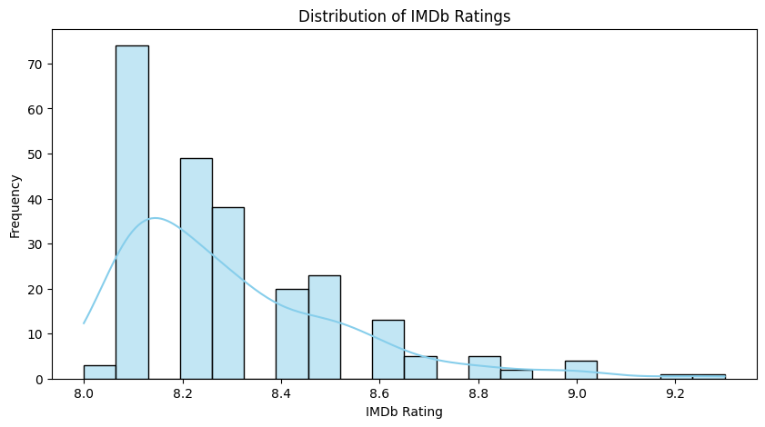

```python
plt.figure(figsize=(10, 5))
sns.histplot(df["IMDb Rating"], bins=20, kde=True, color="skyblue")
plt.title("Distribution of IMDb Ratings")
plt.xlabel("IMDb Rating")
plt.ylabel("Frequency")
plt.show()
```

## 3. IMDb Rating vs. Metascore

- Do movies with high IMDb ratings (above 9) also have high Metascores (above 90)?
- Are there outliers (movies with low Metascores but high IMDb ratings)?

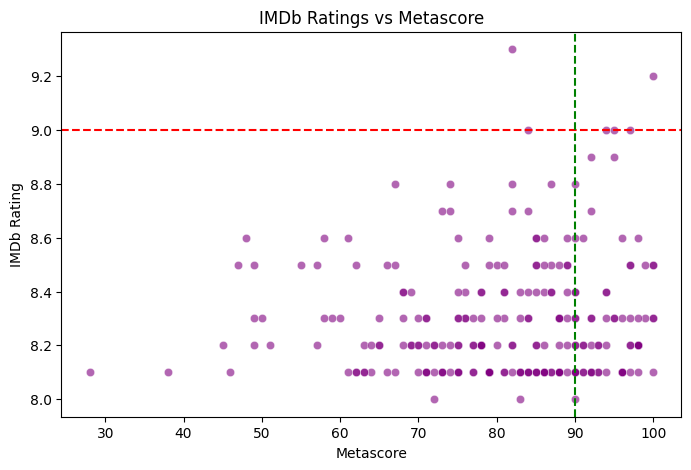

```python
plt.figure(figsize=(8,5))
sns.scatterplot(x=df["Metascore"], y=df["IMDb Rating"], alpha=0.6, color="purple")
plt.axhline(9, color="red", linestyle="dashed")  # Highlight high IMDb rating
plt.axvline(90, color="green", linestyle="dashed")  # Highlight high Metascore
plt.title("IMDb Ratings vs Metascore")
plt.xlabel("Metascore")
plt.ylabel("IMDb Rating")
plt.show()
```

## 4. IMDb Ratings & Metascore Trends Over Time

- Has the number of movies increased significantly over time?
- Did any specific years see a spike in movie releases?

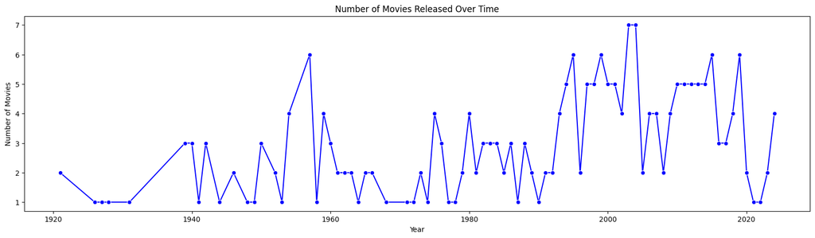

```python
movies_per_year = df.groupby("YEAR").size()

plt.figure(figsize=(20, 5))
sns.lineplot(x=movies_per_year.index, y=movies_per_year.values, marker="o", color="blue")
plt.title("Number of Movies Released Over Time")
plt.xlabel("Year")
plt.ylabel("Number of Movies")
plt.show()
```

5. Rating Comparison for MPAA Ratings
- Do different MPAA Ratings (PG, PG-13, R) have significantly different IMDb Ratings?

[output not shown]

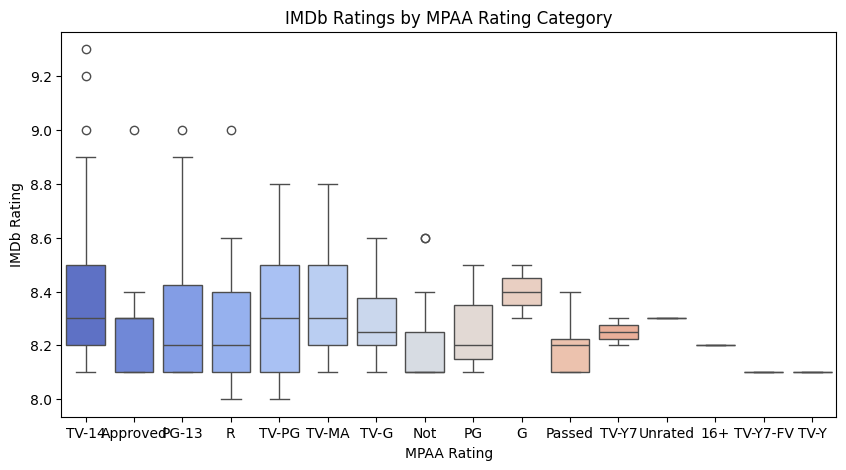

```python
plt.figure(figsize=(10, 5))
sns.boxplot(x=df["MPAA Rating"], y=df["IMDb Rating"], palette="coolwarm")
plt.title("IMDb Ratings by MPAA Rating Category")
plt.xlabel("MPAA Rating")
plt.ylabel("IMDb Rating")
plt.show()
```

## 6. Best Factor for Ratings: Metascore vs. Metascore/Votes

- Which is a better factor for analyzing good movies?

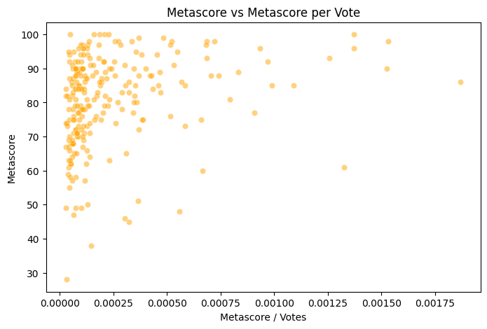

```
Corr : 0.09616927532693909
```

```python
df["Metascore_per_vote"] = df["Metascore"] / df["Votes"]

plt.figure(figsize=(8,5))
sns.scatterplot(x=df["Metascore_per_vote"], y=df["Metascore"], alpha=0.5, color="orange")
plt.title("Metascore vs Metascore per Vote")
plt.xlabel("Metascore / Votes")
plt.ylabel("Metascore")
plt.show()

print('Corr :',df["Metascore"].corr(df["IMDb Rating"]))
```

## 7. Do longer movies (higher Runtime) have better ratings?

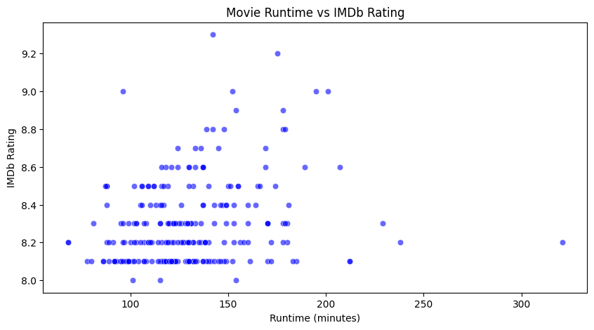

```python
plt.figure(figsize=(10, 5))
sns.scatterplot(x=df["Runtime"], y=df["IMDb Rating"], alpha=0.6, color="blue")
plt.title("Movie Runtime vs IMDb Rating")
plt.xlabel("Runtime (minutes)")
plt.ylabel("IMDb Rating")
plt.show()
```

## 8. Are newer movies (after 2000) rated higher than older classics?

[output not shown]

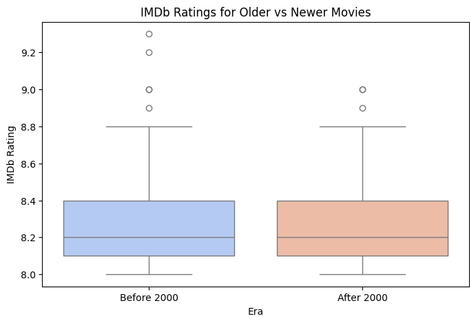

```python
df["Era"] = df["YEAR"].apply(lambda x: "Before 2000" if x < 2000 else "After 2000")

plt.figure(figsize=(8,5))
sns.boxplot(x=df["Era"], y=df["IMDb Rating"], palette="coolwarm")
plt.title("IMDb Ratings for Older vs Newer Movies")
plt.xlabel("Era")
plt.ylabel("IMDb Rating")
plt.show()
```

## 9. Is there a relationship between Votes and IMDb rating?

[figure not shown]

```
corr :  0.6163369171317787
```

```python
plt.figure(figsize=(10, 5))
sns.scatterplot(x=df["Votes"], y=df["IMDb Rating"], alpha=0.5, color="green")
plt.xscale("log")  # Log scale because votes can be very large
plt.title("Number of Votes vs IMDb Rating")
plt.xlabel("Number of Votes (log scale)")
plt.ylabel("IMDb Rating")
plt.show()

print('corr : ',df['IMDb Rating'].corr(df['Votes']))
```

## 10. Do higher Metascore movies also get more votes?

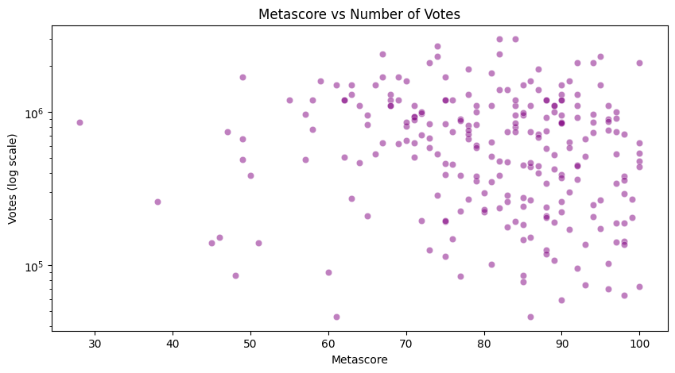

```
corr :  -0.1095802725784205
```

```python
plt.figure(figsize=(10, 5))
sns.scatterplot(x=df["Metascore"], y=df["Votes"], alpha=0.5, color="purple")
plt.yscale("log")  # Log scale for better visualization
plt.title("Metascore vs Number of Votes")
plt.xlabel("Metascore")
plt.ylabel("Votes (log scale)")
plt.show()

print('corr : ',df['Metascore'].corr(df['Votes']),)
```

## 11. Do IMDb ratings correlate with both Metascore and Votes?

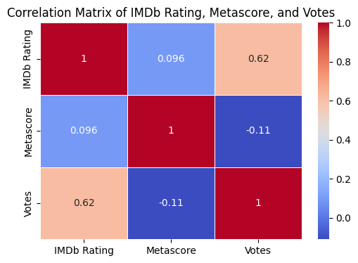

```python
corr_matrix = df[["IMDb Rating", "Metascore", "Votes"]].corr()

plt.figure(figsize=(6,4))
sns.heatmap(corr_matrix, annot=True, cmap="coolwarm", linewidths=0.5)
plt.title("Correlation Matrix of IMDb Rating, Metascore, and Votes")
plt.show()
```

# INSIGHTS :

### 📌 **1. Average IMDb & Metascore Ratings**

- The **average IMDb rating** is **8.3**, and the **average Metascore** is **80.7**.
- Bringing both to the same scale, the **adjusted Metascore** is **8.07**, showing that IMDb and Metascore ratings are quite similar on average.

### 🎞️ **5. MPAA Ratings vs. IMDb Ratings**

- **Different MPAA Ratings do not show a significant difference in IMDb ratings.**

### ⏳ **7. Movie Runtime vs. Ratings**

- **Longer movies do NOT necessarily have better ratings.**

### 🆕 **8. Newer vs. Older Movies**

- **Newer movies (after 2000) are NOT rated higher** than older classics.
- **Both eras (before & after 2000) have similar rating statistics**, meaning IMDb ratings are **consistent over time**.

### 🎟️ **9. Votes vs. IMDb Ratings**

- A **strong positive correlation** exists between **IMDb ratings & number of votes**.
- This means **movies with more votes tend to have higher IMDb ratings**.

### ⭐ **10. Metascore vs. Votes**

- **Higher Metascore movies do NOT get more votes**.

### 🔍 **11. Correlation Matrix Insights**

✨ **These insights help us understand key trends in the movie dataset and how different factors affect ratings and popularity.** 🎥📊